# Lab 2 - BINF 6310

Erin Tsai

2/18/2021

### Question 1

##### In a population, there is a 1/3 chance that a given person has a mutation in some gene.

##### You sample 30 people; what are the odds that exactly 12 of the people have the mutation? In R, plot a probability density function (with dbinom) that shows the distribution for observing exactly (0,1,2,…,30) people with the mutation.

```r
mutation_odds = dbinom(12, 30, (1/3))
```

- The odds of exactly 12 people having the mutation is **0.1101246**.
- Probability density function:

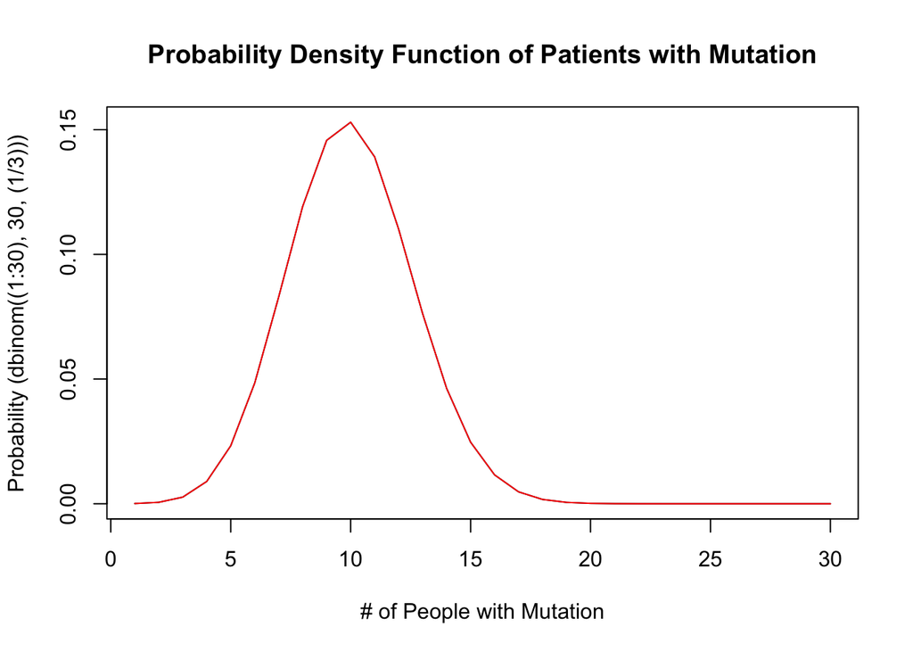

##### What is the mean and variance for the expected number of people with the mutation?

```r
mean_counts = 30*(1/3)
var_counts = (30*(1/3))*(1-(1/3))
```

- The mean for the expected number of people with the mutation is **10**. Which is with the equation np, n being the sample size and p being the probability.
- The variance for the expected number of people with the mutation is **6.6666667**. Which is calculated with the equation np(1-p).

### Question 2

##### The background expected survival rate for a disease is 0.4. You are running a clinical trial. You have 100 patients on a new drug. 47 patients die (and 53 survive).

##### 2A: Plot out the probability density function with the x-axis the number of patients that survive under the null hypothesis.

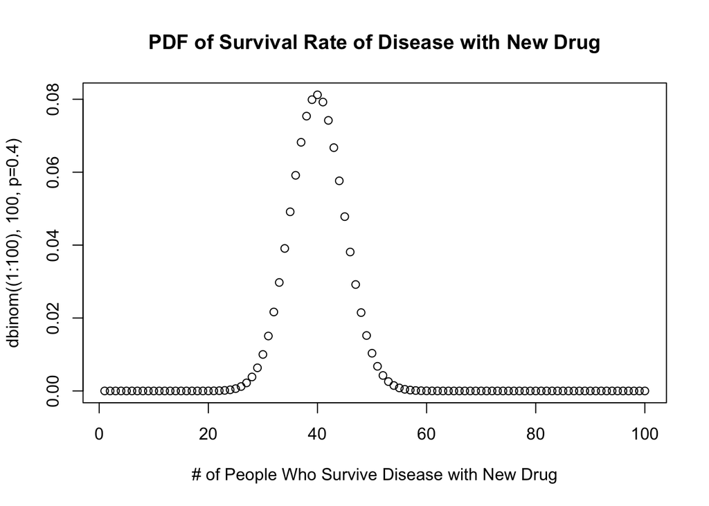

##### 2B: What is the p-value for a null hypothesis that the drug has no effect? (Show the one line of R code that produces this p-value.) doing nothing = people surviving

```r
pval_drug2b = binom.test(53,100,p=0.4)$p.value
```

- The p-value for a null hypothesis that the drug has no effect is **0.0103611**.

##### 2C: What is the p-value for a null hypothesis that the drug does not improve survival? (Show you can get the same answer with binom.test(…) and sum(dbinom(…)).)

```r
pval_drug2c = sum(dbinom(53:100, 100, 0.4))
```

- The p-value for a null hypothesis that the drug does not improve survival is **0.0057606**. This p-value can also found by using binom.test…

```r
binom.test(53,100,p=0.4, alternative = "greater")
```

```
##
##  Exact binomial test
##
## data:  53 and 100
## number of successes = 53, number of trials = 100, p-value = 0.005761
## alternative hypothesis: true probability of success is greater than 0.4
## 95 percent confidence interval:
##  0.4430853 1.0000000
## sample estimates:
## probability of success
##                   0.53
```

### Question 3

##### 3A: Use the rbinom function to simulate 1,000 experiments in which 10,000 patients are sampled with a 1/2 chance of seeing a mutation. (You should get 1,000 numbers back with each # of patients from the 10,000 that had the mutation.) (What is the one line of R code that would produce myVals?)

```r
myVals = rbinom(1000, 10000, p=0.5)
length(myVals)
```

```
## [1] 1000
```

```r
head(myVals)
```

```
## [1] 5024 4989 5019 5052 4982 5039
```

##### 3B: What is the expected mean and variance of the vector in 3A? Show the actual mean and variance are close to the expected mean and variance.

```r
mean_myVals = mean(myVals)
var_myVals = var(myVals)
```

- The mean of myVals is **5000.715**. Which can also be calculated by using the equation np.

```r
10000*0.5
```

```
## [1] 5000
```

- The variance of myVals is **2448.8045796**. Which can also be calculated by using the equation np(1-p).

```r
10000*0.5*(1-0.5)
```

```
## [1] 2500
```

##### 3C: Take the vector that results from 3A. For each element in that vector, calculate a p-value with binom.test(…)$p.value for the null hypothesis that the frequency of the allele in the population for that experiment is 1/2. Graph the histogram of all p-values. What distribution would you expect? Is that what you see?

```r
pvals_3c = vector(mode="double", length = length(myVals))
for(i in 1:length(myVals))
{
  pvals_3c[i] = binom.test(myVals[i],10000,p=0.5)$p.value
}
length(pvals_3c)
```

```
## [1] 1000
```

```r
head(pvals_3c)
```

```
## [1] 0.6383572 0.8336690 0.7113845 0.3030098 0.7263406 0.4413014
```

- I expected the histogram to be closer to a uniform distribution because I assumed the numbers simulated by rbinom would be more similar. Meaning, the 1000 simulations were very similar to the mean of 5000 people having the mutation. There was very little variation.

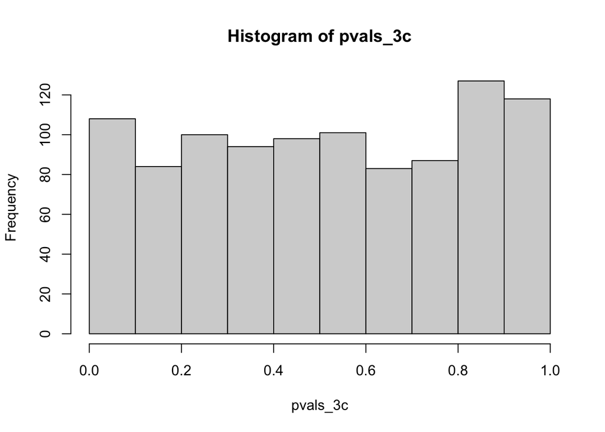

```r
hist(pvals_3c)
```

- The rbinom simulation produced a uniform distribution.

##### 3D: Change the expected value of 1/2 in 3C to some other value. What happens to the p-values in the histogram? Would you expect the same shape of the p-value histogram with expected values of 0.49 as with 0.51? Why or why not?

```r
myVals_3d = rbinom(1000, 10000, p=0.4)
pvals_3d = vector(mode="double", length=length(myVals_3d))
for(i in 1:length(myVals_3d))
{
  pvals_3d[i] = binom.test(myVals[i],10000,p=0.5)$p.value
}
length(pvals_3d)
```

```
## [1] 1000
```

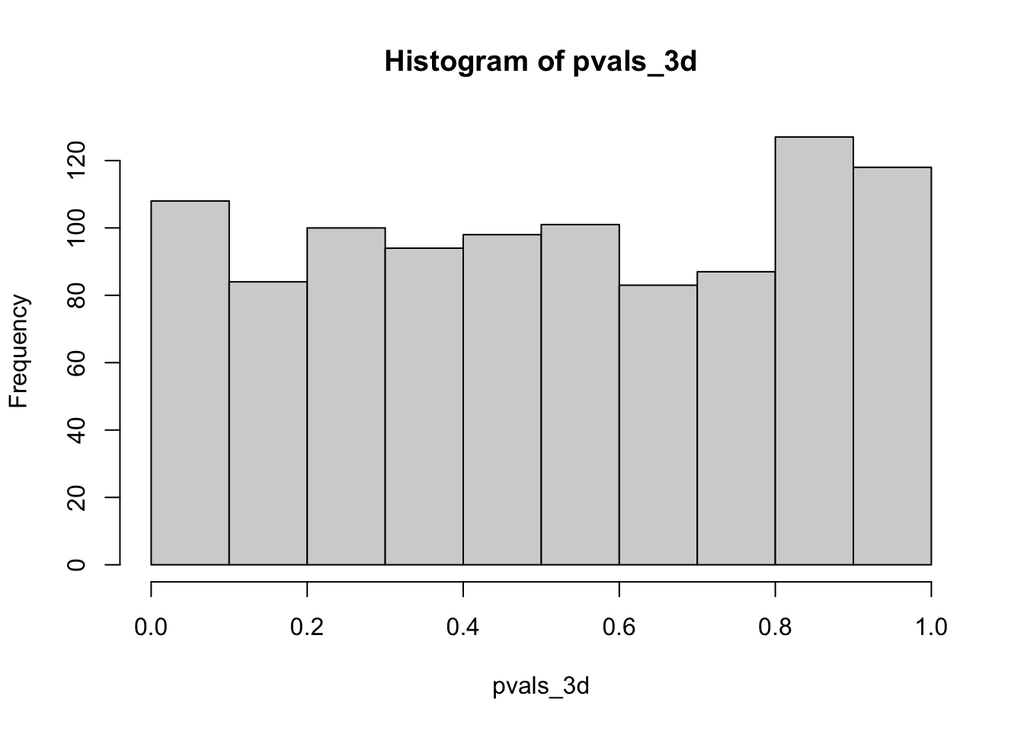

```r
hist(pvals_3d)
```